# What is Big-O?

By wiki, an algorithm is a step-by-step procedure for calculations.  
We expect such an algorithm will give us the "correct" result we're interested in.  
Hence, for any kind of algorithm, we care about mainly on two things:

- Accuracy
- Effeciency

What we don't like: ,

- An algorithm that gives you a wrong answer.
- An algorithm that takes too long to finish.

But, what does it mean by `taking too long to finish`? That is where Big-O steps in.

In order to give a estimation independent to the device or computer you have, we estimate the time for a algorithm to finish in the term of the number of operation it required.

- Including only basic unit of computation. Such as plus(+), minus(-), logical and, ...etc
- Make sure to make a tight estimation of your algorithm (See example below).

## Definition for Big-O

**Definition:**

Let $f(x)$ and $g(x)$ be two functions defined on $\mathbb{R}$ (real number),
one write: $$f(x) \sim \mathcal{O}(g(x))$$
if and only if there exists on positive number $\mathcal{M}$ in $\mathbb{R}$ such that:
$$\lim_{x \rightarrow \infty} \frac{f(x)}{g(x)} \leq \mathcal{M}$$

*[Example]*:
$$f(x)= 6x^3 + \frac{1}{x^2} \sim \mathcal{O}(x^3)$$

**Note:** It is also correct to write: $$f(x) \sim \mathcal{O}(x^6)$$.

Basically speaking, they are two common type of algorithm:

- Brutal Force Algorithm <-- Typically SLOW, but easy to check the accuracy.
- Algorithm developed by smart person. <-- Much more faster but hard to analyse

Here I am going to use sorting problem as example.

# Brutal Force Sorting:

```python
def brutal_sort(to_sort):
    """
    Always find the largest element and the update the array to be returned
    """
    result = []
    for k in range(len(to_sort)):
        tmp = to_sort[0]
        for j in range(1, len(to_sort)):
            if to_sort[j] > tmp:
                tmp = to_sort[j]
        result.append(tmp)
        to_sort.remove(tmp)
    return result
```

```python
import random
a = [11 * random.random() for i in range(10000)]
```

```python
%time a_sorted = brutal_sort(a)
```

```
CPU times: user 4.65 s, sys: 45.1 ms, total: 4.7 s
Wall time: 4.72 s
```

## Pop Quiz

What is the Big-O for this brutal_sort?

**Note: Here we only consider an array with distinct values.**

**Note2: How about array with duplicate values?**

$$\mbox{# of operations for brutal_sort} \sim \mathcal{O}(n^2)$$

# Merge Sort

## The pseudo code for merge sort is as following:

[figure not shown]

## The Implementation

```python
def merge_sort(to_sort):
    """Merge Sort"""
    # if the array is of the base case, return it.
    if len(to_sort) == 2:
        if to_sort[0] < to_sort[1]:
            return [to_sort[1], to_sort[0]]
        else:
            return to_sort
    if len(to_sort) == 1:
        return to_sort
    # Recursively merge sort the left half and the right half of the given array.
    # Then merge the result.
    left = merge_sort(to_sort[:(len(to_sort)/2)])
    right = merge_sort(to_sort[(len(to_sort)/2):])
    i = 0
    j = 0
    result =[]
    for k in range(len(to_sort)):
        if left[i] > right[j]:
            result.append(left[i])
            i += 1
            if i >= len(left):
                for e in right[j:]:
                    result.append(e)
                return result
        else:
            result.append(right[j])
            j += 1
            if j >= len(right):
                for e in left[i:]:
                    result.append(e)
                return result
```

```python
a = [11 * random.random() for i in range(10000)]
```

```python
%time a_sort = merge_sort(a)
```

```
CPU times: user 75.2 ms, sys: 5.1 ms, total: 80.3 ms
Wall time: 77.3 ms
```

# Further Discussion

## Big-O for Merge Sort

- What is the big-O for merge sort?

## Pseudo Code - BFS Algorithm

[figure not shown]

- Find the Big-O for BFS-Distance algorithm.

It is too hard? Let's write some code and do some experiments.

## Demo - Experimental Way to Find the Big-O

```python
%pylab inline
```

```
WARNING: pylab import has clobbered these variables: ['random']
`%matplotlib` prevents importing * from pylab and numpy
```

```python
import numpy as np
```

```python
def mystery_fun(x):
    return 10000 + 3*x + 0.5*x**2 + x**6
```

```python
x = np.linspace(2,10, 100000)
y = mystery_fun(x)
```

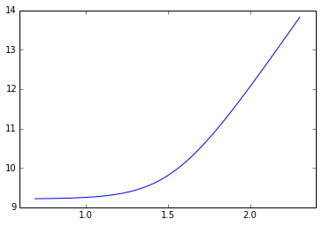

```python
plot(np.log(x), np.log(y))
```

```python
regression = np.polyfit(np.log(x), np.log(y), 1)
regression
```

```
array([ 3.29966881,  5.48452819])
```

```python
x2 = np.linspace(2,10000, 100000)
y2 = mystery_fun(x2)
```

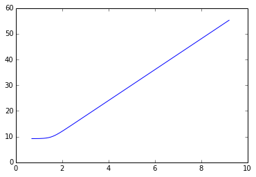

```python
plot(np.log(x2), np.log(y2))
```

```python
regression = np.polyfit(np.log(x2), np.log(y2), 1)
regression
```

```
array([ 5.99472445,  0.04405501])
```

### TextBook

[Problem Solving with Algorithms and Data Structures](http://interactivepython.org/runestone/static/pythonds/index.html)

### Reference

[Algorithmic Thinking](https://class.coursera.org/algorithmicthink-001)

[Algorithms: Design and Analysis, Part 1](https://class.coursera.org/algo-006/)